# Concrete

Alexey Tsvetkov

```r
library(lattice)
library(latticeExtra)
library(corrplot)
library(e1071)
library(MASS)
```

Загрузим данные и переименуем наш целевой параметр `ConcreteCompressiveStrength` в `ConcreteStrength` (для лаконичности).

```r
data <- read.csv("./data/Concrete_Data.csv", comment.char = "#")
names(data)[names(data)=="ConcreteCompressiveStrength"] <- 'ConcreteStrength'
```

# Данные

```r
summary(data)
```

```
##      Cement      BlastFurnaceSlag     FlyAsh           Water
##  Min.   :102.0   Min.   :  0.0    Min.   :  0.00   Min.   :121.8
##  1st Qu.:192.4   1st Qu.:  0.0    1st Qu.:  0.00   1st Qu.:164.9
##  Median :272.9   Median : 22.0    Median :  0.00   Median :185.0
##  Mean   :281.2   Mean   : 73.9    Mean   : 54.19   Mean   :181.6
##  3rd Qu.:350.0   3rd Qu.:142.9    3rd Qu.:118.30   3rd Qu.:192.0
##  Max.   :540.0   Max.   :359.4    Max.   :200.10   Max.   :247.0
##  Superplasticizer CoarseAggregate  FineAggregate        Age
##  Min.   : 0.000   Min.   : 801.0   Min.   :594.0   Min.   :  1.00
##  1st Qu.: 0.000   1st Qu.: 932.0   1st Qu.:731.0   1st Qu.:  7.00
##  Median : 6.400   Median : 968.0   Median :779.5   Median : 28.00
##  Mean   : 6.205   Mean   : 972.9   Mean   :773.6   Mean   : 45.66
##  3rd Qu.:10.200   3rd Qu.:1029.4   3rd Qu.:824.0   3rd Qu.: 56.00
##  Max.   :32.200   Max.   :1145.0   Max.   :992.6   Max.   :365.00
##  ConcreteStrength
##  Min.   : 2.33
##  1st Qu.:23.71
##  Median :34.45
##  Mean   :35.82
##  3rd Qu.:46.13
##  Max.   :82.60
```

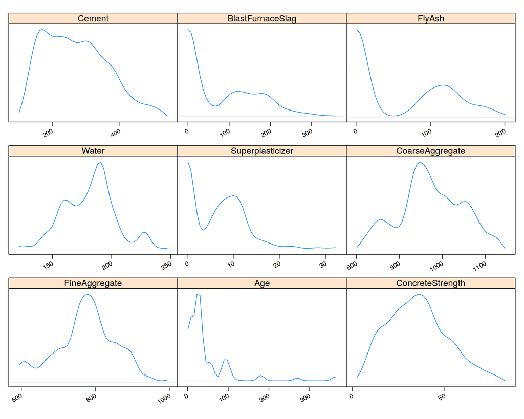

```r
marginal.plot(data)
```

Заметим, что `Age` является дискретной величиной со значениями от 1 до 365 (возраст измеряется в днях). При этом данные по возрасту распределены не нормально, поэтому возможно их будет иметь смысл прологорифмировать.

Построим графики зависимостей и корреляции всех параметров со всеми.

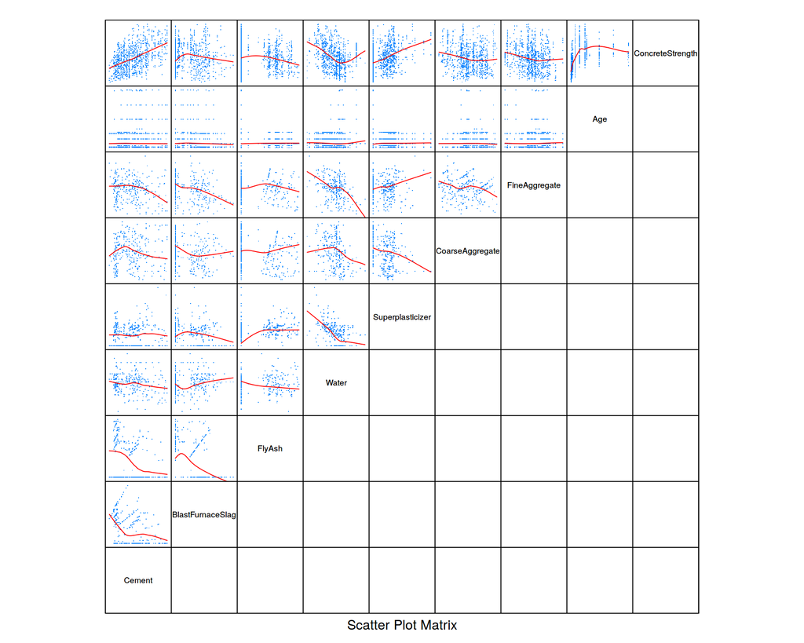

```r
splom(
    ~data,
    data,
    upper.panel=function(x, y, ...) { panel.xyplot(x, y, ...); panel.loess(x, y, ..., col='red') },
    lower.panel=function(x, y, ...) { },
    pscale=0,
    varname.cex=0.6,
    par.settings=simpleTheme(pch='.', cex=1)
  )
```

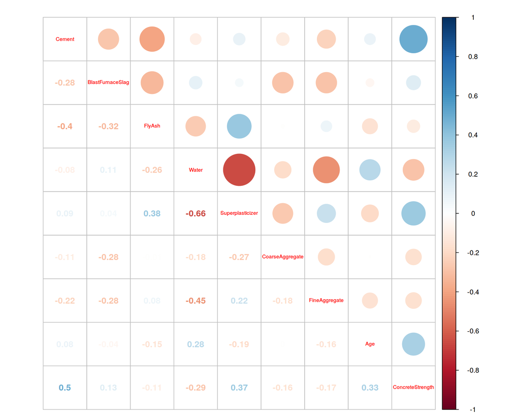

```r
corrplot.mixed(cor(data), tl.cex=0.6)
```

Многие параметры также коррелируют между собой (сильнее всего `Water` и `Superplasticizer`).

Посмотрим повлияют ли трансформации параметров на зависимость целевого параметра.

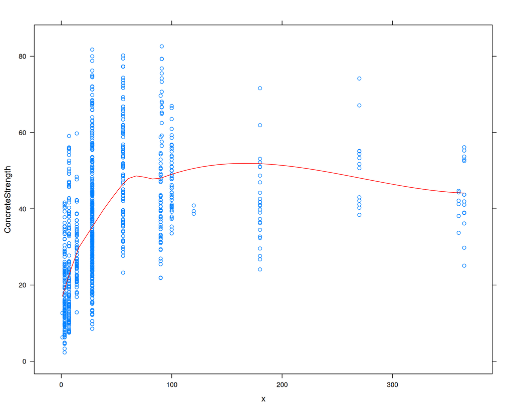

```r
strengthPlot = function(x) {
  xyplot(ConcreteStrength ~ x, data, panel = function(...) { panel.xyplot(...); panel.loess(..., col='red') })
}

strengthPlot(data$Age)
```

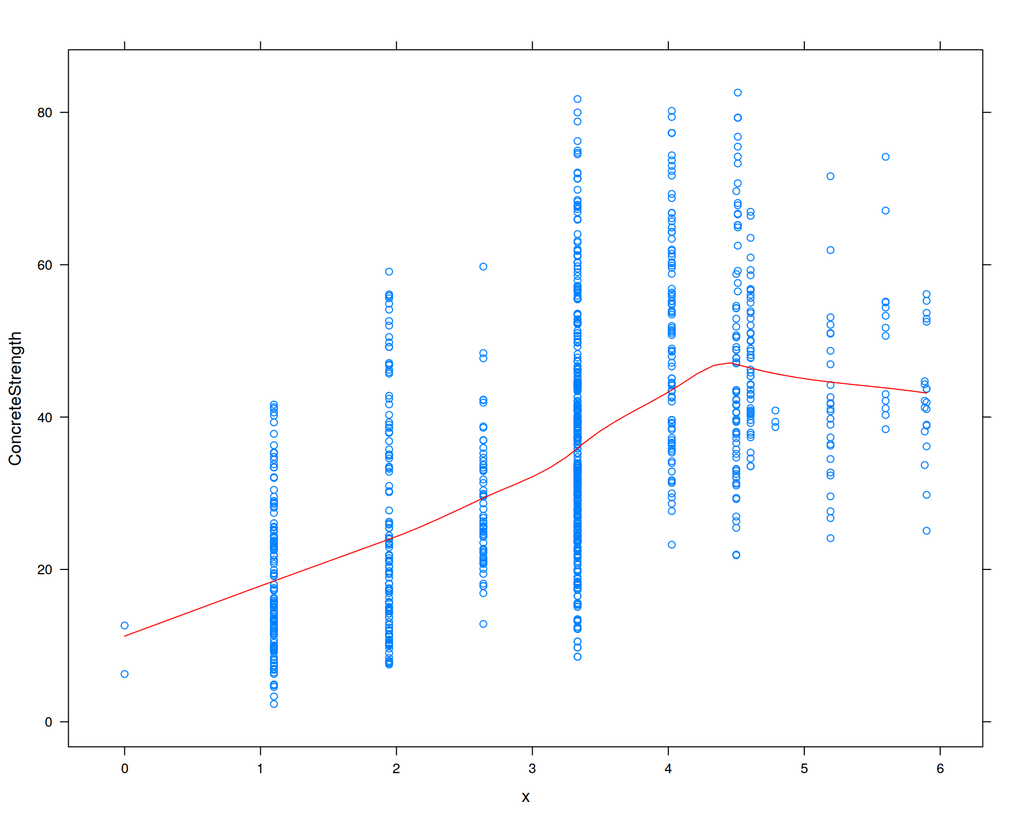

```r
data$Age.log <- log(data$Age)
strengthPlot(data$Age.log)
```

Ага, после логарифмирования зависимость от возраста стала до определённого возраста расти, а потом уменьшаться (видимо, с какого-то момента цемент начинает стареть).

Возможно имеет смысл ввести фактор молодости.

```r
data$Age.young <- sapply(data$Age.log, function(x) { max(0, 4-x) })
```

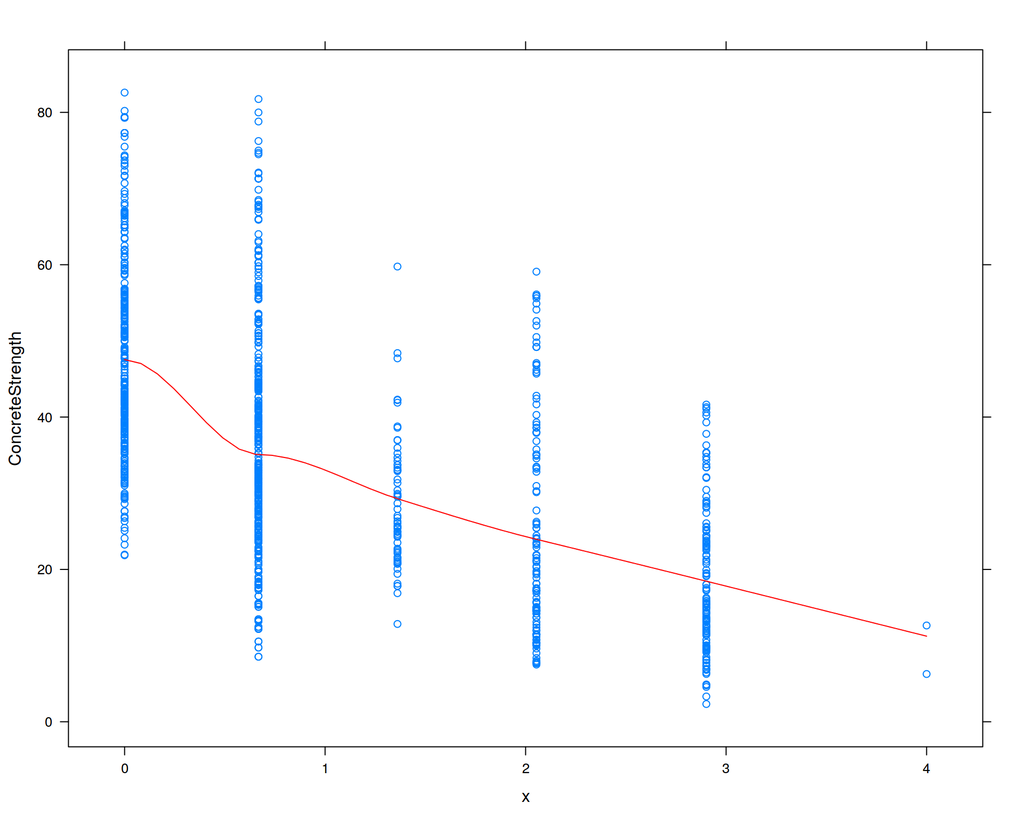

```r
strengthPlot(data$Age.young)
```

Посмотрим подробнее на воду.

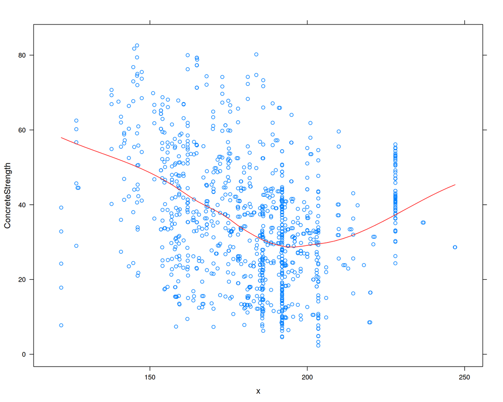

```r
strengthPlot(data$Water)
```

Зависимость немонотонная, возможно стоит попробовать учесть фактор `Water < 185` (медиана).

# Тестирование моделей

```r
cv <- function(m) {
  tune(lm, m$call$formula, data = data, tunecontrol = tune.control(sampling = "cross"))
}
```

Для начала попробуем все оригинальные параметры.

```r
fit1 <- lm(ConcreteStrength ~ Cement + BlastFurnaceSlag + FlyAsh + Water + Superplasticizer + CoarseAggregate + FineAggregate + Age, data)
summary(fit1)
```

```
##
## Call:
## lm(formula = ConcreteStrength ~ Cement + BlastFurnaceSlag + FlyAsh +
##     Water + Superplasticizer + CoarseAggregate + FineAggregate +
##     Age, data = data)
##
## Residuals:
##     Min      1Q  Median      3Q     Max
## -28.654  -6.302   0.703   6.569  34.450
##
## Coefficients:
##                    Estimate Std. Error t value Pr(>|t|)
## (Intercept)      -23.331214  26.585504  -0.878 0.380372
## Cement             0.119804   0.008489  14.113  < 2e-16 ***
## BlastFurnaceSlag   0.103866   0.010136  10.247  < 2e-16 ***
## FlyAsh             0.087934   0.012583   6.988 5.02e-12 ***
## Water             -0.149918   0.040177  -3.731 0.000201 ***
## Superplasticizer   0.292225   0.093424   3.128 0.001810 **
## CoarseAggregate    0.018086   0.009392   1.926 0.054425 .
## FineAggregate      0.020190   0.010702   1.887 0.059491 .
## Age                0.114222   0.005427  21.046  < 2e-16 ***
## ---
## Signif. codes:  0 '***' 0.001 '**' 0.01 '*' 0.05 '.' 0.1 ' ' 1
##
## Residual standard error: 10.4 on 1021 degrees of freedom
## Multiple R-squared:  0.6155, Adjusted R-squared:  0.6125
## F-statistic: 204.3 on 8 and 1021 DF,  p-value: < 2.2e-16
```

```r
cv(fit1)
```

```
##
## Error estimation of 'lm' using 10-fold cross validation: 109.2967
```

Попробуем заменить `Age` на `Age.log`.

```r
fit2 <- lm(ConcreteStrength ~ Cement + BlastFurnaceSlag + FlyAsh + Water + Superplasticizer + CoarseAggregate + FineAggregate + Age.log, data)
summary(fit2)
```

```
##
## Call:
## lm(formula = ConcreteStrength ~ Cement + BlastFurnaceSlag + FlyAsh +
##     Water + Superplasticizer + CoarseAggregate + FineAggregate +
##     Age.log, data = data)
##
## Residuals:
##      Min       1Q   Median       3Q      Max
## -22.7754  -4.2774  -0.2914   4.0177  29.4003
##
## Coefficients:
##                    Estimate Std. Error t value Pr(>|t|)
## (Intercept)      -77.533388  18.330800  -4.230 2.55e-05 ***
## Cement             0.134857   0.005849  23.055  < 2e-16 ***
## BlastFurnaceSlag   0.115945   0.006965  16.647  < 2e-16 ***
## FlyAsh             0.094391   0.008625  10.944  < 2e-16 ***
## Water             -0.128817   0.027564  -4.673 3.36e-06 ***
## Superplasticizer   0.118822   0.064366   1.846   0.0652 .
## CoarseAggregate    0.029681   0.006462   4.593 4.91e-06 ***
## FineAggregate      0.035989   0.007366   4.886 1.19e-06 ***
## Age.log            8.746595   0.191768  45.610  < 2e-16 ***
## ---
## Signif. codes:  0 '***' 0.001 '**' 0.01 '*' 0.05 '.' 0.1 ' ' 1
##
## Residual standard error: 7.145 on 1021 degrees of freedom
## Multiple R-squared:  0.8185, Adjusted R-squared:  0.8171
## F-statistic: 575.6 on 8 and 1021 DF,  p-value: < 2.2e-16
```

```r
cv(fit2)
```

```
##
## Error estimation of 'lm' using 10-fold cross validation: 51.82323
```

Попробуем учесть молодость.

```r
fit3 <- lm(ConcreteStrength ~ Cement + BlastFurnaceSlag + FlyAsh + Water + Superplasticizer + CoarseAggregate + FineAggregate + Age.log * Age.young, data)
summary(fit3)
```

```
##
## Call:
## lm(formula = ConcreteStrength ~ Cement + BlastFurnaceSlag + FlyAsh +
##     Water + Superplasticizer + CoarseAggregate + FineAggregate +
##     Age.log * Age.young, data = data)
##
## Residuals:
##      Min       1Q   Median       3Q      Max
## -21.0403  -4.7106  -0.3715   3.9365  28.9387
##
## Coefficients:
##                     Estimate Std. Error t value Pr(>|t|)
## (Intercept)       -46.502111  18.568104  -2.504 0.012421 *
## Cement              0.132698   0.005778  22.966  < 2e-16 ***
## BlastFurnaceSlag    0.111015   0.006860  16.183  < 2e-16 ***
## FlyAsh              0.085585   0.008532  10.031  < 2e-16 ***
## Water              -0.122477   0.026988  -4.538 6.35e-06 ***
## Superplasticizer    0.086526   0.062822   1.377 0.168717
## CoarseAggregate     0.027935   0.006356   4.395 1.22e-05 ***
## FineAggregate       0.032011   0.007279   4.398 1.21e-05 ***
## Age.log             3.102063   0.768931   4.034 5.89e-05 ***
## Age.young          -5.791469   0.808548  -7.163 1.51e-12 ***
## Age.log:Age.young  -1.047698   0.308117  -3.400 0.000699 ***
## ---
## Signif. codes:  0 '***' 0.001 '**' 0.01 '*' 0.05 '.' 0.1 ' ' 1
##
## Residual standard error: 6.957 on 1019 degrees of freedom
## Multiple R-squared:  0.8282, Adjusted R-squared:  0.8266
## F-statistic: 491.4 on 10 and 1019 DF,  p-value: < 2.2e-16
```

```r
cv(fit3)
```

```
##
## Error estimation of 'lm' using 10-fold cross validation: 48.91366
```

Попробуем добавить ешё разных факторов и взаимодействий.

```r
data$Water.f <- (data$Water < 185)
data$FineAggregate.f <- (data$FineAggregate < 800)
data$FlyAsh.f <- (data$FlyAsh > 90)
data$BlastFurnaceSlag.f <- (data$BlastFurnaceSlag > 90)
data$Superplasticizer.f <- (data$Superplasticizer > 0)
data$CoarseAggregate.f <- (data$CoarseAggregate < 1000)
data$WS <- data$Water * data$Superplasticizer

fit4 <- lm(ConcreteStrength ~ Cement + Cement:CoarseAggregate + Cement:FineAggregate + Water:CoarseAggregate + BlastFurnaceSlag*BlastFurnaceSlag.f + FlyAsh*FlyAsh.f +  Water*Water.f + Water:Superplasticizer + WS + Water:FineAggregate  + Superplasticizer * Superplasticizer.f  + CoarseAggregate*CoarseAggregate.f + FineAggregate*FineAggregate.f + CoarseAggregate * FineAggregate + Age.log * Age.young, data)
summary(fit4)
```

```
##
## Call:
## lm(formula = ConcreteStrength ~ Cement + Cement:CoarseAggregate +
##     Cement:FineAggregate + Water:CoarseAggregate + BlastFurnaceSlag *
##     BlastFurnaceSlag.f + FlyAsh * FlyAsh.f + Water * Water.f +
##     Water:Superplasticizer + WS + Water:FineAggregate + Superplasticizer *
##     Superplasticizer.f + CoarseAggregate * CoarseAggregate.f +
##     FineAggregate * FineAggregate.f + CoarseAggregate * FineAggregate +
##     Age.log * Age.young, data = data)
##
## Residuals:
##      Min       1Q   Median       3Q      Max
## -25.1027  -4.2330  -0.1247   3.7739  24.6607
##
## Coefficients: (2 not defined because of singularities)
##                                           Estimate Std. Error t value
## (Intercept)                             -5.293e+01  8.507e+01  -0.622
## Cement                                   5.659e-03  4.199e-02   0.135
## BlastFurnaceSlag                         1.514e-01  1.912e-02   7.914
## BlastFurnaceSlag.fTRUE                   4.548e+00  1.138e+00   3.997
## FlyAsh                                   1.779e-02  1.687e-02   1.054
## FlyAsh.fTRUE                             5.325e+00  1.788e+00   2.977
## Water                                    5.792e-01  3.125e-01   1.854
## Water.fTRUE                              3.063e+01  1.256e+01   2.439
## WS                                      -7.390e-03  3.022e-03  -2.446
## Superplasticizer                         1.026e+00  4.876e-01   2.105
## Superplasticizer.fTRUE                   5.159e+00  1.174e+00   4.395
## CoarseAggregate                          3.095e-02  7.426e-02   0.417
## CoarseAggregate.fTRUE                   -2.040e+01  1.252e+01  -1.629
## FineAggregate                           -1.201e-01  7.205e-02  -1.667
## FineAggregate.fTRUE                     -1.755e+01  1.073e+01  -1.636
## Age.log                                  3.054e+00  7.264e-01   4.204
## Age.young                               -5.872e+00  7.805e-01  -7.523
## Cement:CoarseAggregate                   1.308e-04  2.977e-05   4.394
## Cement:FineAggregate                     1.133e-05  2.867e-05   0.395
## CoarseAggregate:Water                   -7.699e-04  2.442e-04  -3.152
## BlastFurnaceSlag:BlastFurnaceSlag.fTRUE -6.041e-02  1.960e-02  -3.083
## FlyAsh:FlyAsh.fTRUE                      7.903e-03  1.968e-02   0.401
## Water:Water.fTRUE                       -1.439e-01  6.821e-02  -2.110
## Water:Superplasticizer                          NA         NA      NA
```

[output cut: 28 more lines]

```
## FlyAsh:FlyAsh.fTRUE                      0.68814
## Water:Water.fTRUE                        0.03511 *
## Water:Superplasticizer                        NA
## FineAggregate:Water                      0.10158
## Superplasticizer:Superplasticizer.fTRUE       NA
## CoarseAggregate:CoarseAggregate.fTRUE    0.12058
## FineAggregate:FineAggregate.fTRUE        0.04671 *
## CoarseAggregate:FineAggregate            0.05641 .
## Age.log:Age.young                        0.00550 **
## ---
## Signif. codes:  0 '***' 0.001 '**' 0.01 '*' 0.05 '.' 0.1 ' ' 1
##
## Residual standard error: 6.234 on 1002 degrees of freedom
## Multiple R-squared:  0.8644, Adjusted R-squared:  0.8608
## F-statistic: 236.6 on 27 and 1002 DF,  p-value: < 2.2e-16
```

```r
cv(fit4)
```

```
##
## Error estimation of 'lm' using 10-fold cross validation: 40.90129
```

# AIC

Попробуем запустить AIC на лучших моделях.

```r
fit3.aic <- stepAIC(fit3)
```

```
## Start:  AIC=4006.93
## ConcreteStrength ~ Cement + BlastFurnaceSlag + FlyAsh + Water +
##     Superplasticizer + CoarseAggregate + FineAggregate + Age.log *
##     Age.young
##
##                     Df Sum of Sq   RSS    AIC
## - Superplasticizer   1      91.8 49416 4006.8
## <none>                           49324 4006.9
## - Age.log:Age.young  1     559.7 49884 4016.5
## - CoarseAggregate    1     935.1 50260 4024.3
## - FineAggregate      1     936.3 50261 4024.3
## - Water              1     996.9 50321 4025.5
## - FlyAsh             1    4870.9 54195 4101.9
## - BlastFurnaceSlag   1   12676.9 62001 4240.5
## - Cement             1   25530.6 74855 4434.6
##
## Step:  AIC=4006.84
## ConcreteStrength ~ Cement + BlastFurnaceSlag + FlyAsh + Water +
##     CoarseAggregate + FineAggregate + Age.log + Age.young + Age.log:Age.young
##
##                     Df Sum of Sq   RSS    AIC
## <none>                           49416 4006.8
## - Age.log:Age.young  1     576.2 49992 4016.8
## - CoarseAggregate    1     844.5 50261 4022.3
## - FineAggregate      1     868.3 50285 4022.8
## - Water              1    1837.8 51254 4042.5
## - FlyAsh             1    5089.4 54506 4105.8
## - BlastFurnaceSlag   1   12653.4 62070 4239.7
## - Cement             1   25508.7 74925 4433.5
```

```r
summary(fit3.aic)
```

```
##
## Call:
## lm(formula = ConcreteStrength ~ Cement + BlastFurnaceSlag + FlyAsh +
##     Water + CoarseAggregate + FineAggregate + Age.log + Age.young +
##     Age.log:Age.young, data = data)
##
## Residuals:
##      Min       1Q   Median       3Q      Max
## -20.8772  -4.7368  -0.3521   3.9264  28.7044
##
## Coefficients:
##                     Estimate Std. Error t value Pr(>|t|)
## (Intercept)       -38.082660  17.540720  -2.171 0.030154 *
## Cement              0.132637   0.005780  22.946  < 2e-16 ***
## BlastFurnaceSlag    0.110905   0.006862  16.161  < 2e-16 ***
## FlyAsh              0.086918   0.008480  10.249  < 2e-16 ***
## Water              -0.141869   0.023034  -6.159 1.05e-09 ***
## CoarseAggregate     0.024904   0.005965   4.175 3.23e-05 ***
## FineAggregate       0.030452   0.007193   4.233 2.51e-05 ***
## Age.log             3.053377   0.768455   3.973 7.58e-05 ***
## Age.young          -5.860633   0.807341  -7.259 7.71e-13 ***
## Age.log:Age.young  -1.062423   0.308066  -3.449 0.000586 ***
## ---
## Signif. codes:  0 '***' 0.001 '**' 0.01 '*' 0.05 '.' 0.1 ' ' 1
##
## Residual standard error: 6.96 on 1020 degrees of freedom
## Multiple R-squared:  0.8279, Adjusted R-squared:  0.8264
## F-statistic: 545.3 on 9 and 1020 DF,  p-value: < 2.2e-16
```

```r
cv(fit3.aic)
```

```
##
## Error estimation of 'lm' using 10-fold cross validation: 49.3166
```

```r
fit4.aic <- stepAIC(fit4)
```

```
## Start:  AIC=3797.3
## ConcreteStrength ~ Cement + Cement:CoarseAggregate + Cement:FineAggregate +
##     Water:CoarseAggregate + BlastFurnaceSlag * BlastFurnaceSlag.f +
##     FlyAsh * FlyAsh.f + Water * Water.f + Water:Superplasticizer +
##     WS + Water:FineAggregate + Superplasticizer * Superplasticizer.f +
##     CoarseAggregate * CoarseAggregate.f + FineAggregate * FineAggregate.f +
##     CoarseAggregate * FineAggregate + Age.log * Age.young
##
##
## Step:  AIC=3797.3
## ConcreteStrength ~ Cement + BlastFurnaceSlag + BlastFurnaceSlag.f +
##     FlyAsh + FlyAsh.f + Water + Water.f + WS + Superplasticizer +
##     Superplasticizer.f + CoarseAggregate + CoarseAggregate.f +
##     FineAggregate + FineAggregate.f + Age.log + Age.young + Cement:CoarseAggregate +
##     Cement:FineAggregate + CoarseAggregate:Water + BlastFurnaceSlag:BlastFurnaceSlag.f +
##     FlyAsh:FlyAsh.f + Water:Water.f + Water:Superplasticizer +
##     FineAggregate:Water + CoarseAggregate:CoarseAggregate.f +
##     FineAggregate:FineAggregate.f + CoarseAggregate:FineAggregate +
##     Age.log:Age.young
##
##
## Step:  AIC=3797.3
## ConcreteStrength ~ Cement + BlastFurnaceSlag + BlastFurnaceSlag.f +
##     FlyAsh + FlyAsh.f + Water + Water.f + WS + Superplasticizer +
##     Superplasticizer.f + CoarseAggregate + CoarseAggregate.f +
##     FineAggregate + FineAggregate.f + Age.log + Age.young + Cement:CoarseAggregate +
##     Cement:FineAggregate + Water:CoarseAggregate + BlastFurnaceSlag:BlastFurnaceSlag.f +
##     FlyAsh:FlyAsh.f + Water:Water.f + Water:FineAggregate + CoarseAggregate:CoarseAggregate.f +
##     FineAggregate:FineAggregate.f + CoarseAggregate:FineAggregate +
##     Age.log:Age.young
##
##                                       Df Sum of Sq   RSS    AIC
## - Cement:FineAggregate                 1      6.07 38941 3795.5
## - FlyAsh:FlyAsh.f                      1      6.26 38941 3795.5
## <none>                                             38935 3797.3
## - CoarseAggregate:CoarseAggregate.f    1     93.79 39029 3797.8
## - Water:FineAggregate                  1    104.35 39039 3798.1
## - CoarseAggregate:FineAggregate        1    141.76 39077 3799.0
## - FineAggregate:FineAggregate.f        1    154.09 39089 3799.4
## - Superplasticizer                     1    172.16 39107 3799.8
```

[output cut: 45 more lines]

```
## <none>                                             38948 3793.6
## - CoarseAggregate:CoarseAggregate.f    1     95.15 39043 3794.2
## - Water:FineAggregate                  1     98.22 39046 3794.2
## - FlyAsh                               1    106.60 39054 3794.5
## - CoarseAggregate:FineAggregate        1    136.55 39084 3795.3
## - Superplasticizer                     1    166.05 39114 3796.0
## - Water:Water.f                        1    192.42 39140 3796.7
## - FineAggregate:FineAggregate.f        1    193.78 39142 3796.8
## - WS                                   1    226.41 39174 3797.6
## - Age.log:Age.young                    1    299.09 39247 3799.5
## - BlastFurnaceSlag:BlastFurnaceSlag.f  1    357.11 39305 3801.0
## - Water:CoarseAggregate                1    382.63 39331 3801.7
## - Superplasticizer.f                   1    749.58 39697 3811.3
## - Cement:CoarseAggregate               1    787.88 39736 3812.3
## - FlyAsh.f                             1    844.62 39792 3813.7
```

```r
summary(fit4.aic)
```

```
##
## Call:
## lm(formula = ConcreteStrength ~ Cement + BlastFurnaceSlag + BlastFurnaceSlag.f +
##     FlyAsh + FlyAsh.f + Water + Water.f + WS + Superplasticizer +
##     Superplasticizer.f + CoarseAggregate + CoarseAggregate.f +
##     FineAggregate + FineAggregate.f + Age.log + Age.young + Cement:CoarseAggregate +
##     Water:CoarseAggregate + BlastFurnaceSlag:BlastFurnaceSlag.f +
##     Water:Water.f + Water:FineAggregate + CoarseAggregate:CoarseAggregate.f +
##     FineAggregate:FineAggregate.f + CoarseAggregate:FineAggregate +
##     Age.log:Age.young, data = data)
##
## Residuals:
##     Min      1Q  Median      3Q     Max
## -25.076  -4.205  -0.051   3.761  24.632
##
## Coefficients:
##                                           Estimate Std. Error t value
## (Intercept)                             -5.410e+01  8.489e+01  -0.637
## Cement                                   1.884e-02  2.818e-02   0.669
## BlastFurnaceSlag                         1.500e-01  1.895e-02   7.916
## BlastFurnaceSlag.fTRUE                   4.450e+00  1.121e+00   3.968
## FlyAsh                                   2.192e-02  1.322e-02   1.658
## FlyAsh.fTRUE                             5.830e+00  1.249e+00   4.666
## Water                                    5.639e-01  3.099e-01   1.820
## Water.fTRUE                              3.162e+01  1.239e+01   2.553
## WS                                      -7.159e-03  2.963e-03  -2.416
## Superplasticizer                         9.934e-01  4.801e-01   2.069
## Superplasticizer.fTRUE                   5.007e+00  1.139e+00   4.396
## CoarseAggregate                          2.981e-02  7.341e-02   0.406
## CoarseAggregate.fTRUE                   -2.055e+01  1.249e+01  -1.646
## FineAggregate                           -1.134e-01  7.105e-02  -1.596
## FineAggregate.fTRUE                     -1.916e+01  1.030e+01  -1.860
## Age.log                                  3.055e+00  7.251e-01   4.213
## Age.young                               -5.875e+00  7.783e-01  -7.548
## Cement:CoarseAggregate                   1.256e-04  2.787e-05   4.507
## Water:CoarseAggregate                   -7.456e-04  2.374e-04  -3.141
## BlastFurnaceSlag:BlastFurnaceSlag.fTRUE -5.861e-02  1.932e-02  -3.034
## Water:Water.fTRUE                       -1.495e-01  6.713e-02  -2.227
## Water:FineAggregate                      3.020e-04  1.898e-04   1.591
## CoarseAggregate:CoarseAggregate.fTRUE    1.930e-02  1.233e-02   1.566
```

[output cut: 21 more lines]

```
## Cement:CoarseAggregate                  7.36e-06 ***
## Water:CoarseAggregate                    0.00174 **
## BlastFurnaceSlag:BlastFurnaceSlag.fTRUE  0.00247 **
## Water:Water.fTRUE                        0.02616 *
## Water:FineAggregate                      0.11187
## CoarseAggregate:CoarseAggregate.fTRUE    0.11764
## FineAggregate:FineAggregate.fTRUE        0.02564 *
## CoarseAggregate:FineAggregate            0.06093 .
## Age.log:Age.young                        0.00559 **
## ---
## Signif. codes:  0 '***' 0.001 '**' 0.01 '*' 0.05 '.' 0.1 ' ' 1
##
## Residual standard error: 6.228 on 1004 degrees of freedom
## Multiple R-squared:  0.8644, Adjusted R-squared:  0.861
## F-statistic:   256 on 25 and 1004 DF,  p-value: < 2.2e-16
```

```r
cv(fit4.aic)
```

```
##
## Error estimation of 'lm' using 10-fold cross validation: 40.41404
```